# Homework 06

STAT 432

Author

Haoran Sun

Published

October 2, 2026

## Question 1: Compare KNN and logistic regression

Use breast-cancer.csv, which contains 569 cases from the [Wisconsin Diagnostic Breast Cancer dataset](https://archive.ics.uci.edu/dataset/17/breast%2Bcancer%2Bwisconsin%2Bdiagnostic). Predict `y` (1 for malignant and 0 for benign) using `mean_radius`, `mean_texture`, and `mean_smoothness`.

Set a random seed and randomly split the observations into 70% training and 30% test data. Use the same split for every model. Standardize the predictors using the training means and standard deviations, and apply the same transformations to the test data.

Fit ordinary logistic regression with an intercept and no penalty, and KNN with Euclidean distance, equal neighbor weights, and

$$k\in\{5,15,25,35,45\}.$$

Using the estimated probabilities for `y = 1` on the test data, plot all six ROC curves in one figure and report their AUC values. Which of the six fitted models do you prefer? Give a brief justification based on your results.

### Answer 1

```python
import numpy as np
import matplotlib.pyplot as plt
from sklearn.model_selection import train_test_split
from sklearn.preprocessing import StandardScaler
from sklearn.linear_model import LogisticRegression
from sklearn.neighbors import KNeighborsClassifier
from sklearn.metrics import roc_curve, roc_auc_score

seed = 43206
data = np.genfromtxt("data/breast-cancer.csv", delimiter=",", names=True)
X = np.column_stack([data[name] for name in
                     ["mean_radius", "mean_texture", "mean_smoothness"]])
y = data["y"].astype(int)
X_train, X_test, y_train, y_test = train_test_split(
    X, y, test_size=0.30, random_state=seed
)
scaler = StandardScaler()
X_train = scaler.fit_transform(X_train)
X_test = scaler.transform(X_test)

models = {"Logistic regression": LogisticRegression(
    C=np.inf, fit_intercept=True, max_iter=1000
)}
models.update({f"KNN (k={k})": KNeighborsClassifier(
    n_neighbors=k, weights="uniform", metric="euclidean"
) for k in [5, 15, 25, 35, 45]})

print(f"Seed: {seed}; training: {len(y_train)}; test: {len(y_test)}")
```

```
Seed: 43206; training: 398; test: 171
```

```python
print(f"{'Model':<22} {'Test AUC':>8}")
```

```
Model                  Test AUC
```

```python
fig, ax = plt.subplots(figsize=(7, 5))
auc_values = {}
for name, model in models.items():
    model.fit(X_train, y_train)
    probabilities = model.predict_proba(X_test)[:, 1]
    fpr, tpr, _ = roc_curve(y_test, probabilities)
    auc_values[name] = roc_auc_score(y_test, probabilities)
    print(f"{name:<22} {auc_values[name]:8.4f}")
    ax.plot(fpr, tpr, label=f"{name}: AUC = {auc_values[name]:.4f}")
```

```
LogisticRegression(C=inf, max_iter=1000)
Logistic regression      0.9857
KNeighborsClassifier(metric='euclidean')
KNN (k=5)                0.9535
KNeighborsClassifier(metric='euclidean', n_neighbors=15)
KNN (k=15)               0.9808
KNeighborsClassifier(metric='euclidean', n_neighbors=25)
KNN (k=25)               0.9814
KNeighborsClassifier(metric='euclidean', n_neighbors=35)
KNN (k=35)               0.9826
KNeighborsClassifier(metric='euclidean', n_neighbors=45)
KNN (k=45)               0.9834
```

```python
ax.plot([0, 1], [0, 1], "k--", alpha=0.4)
ax.set(xlabel="False positive rate", ylabel="True positive rate",
       title="Test ROC curves", xlim=(0, 1), ylim=(0, 1.02))
```

```
[Text(0.5, 0, 'False positive rate'), Text(0, 0.5, 'True positive rate'), Text(0.5, 1.0, 'Test ROC curves'), (0.0, 1.0), (0.0, 1.02)]
```

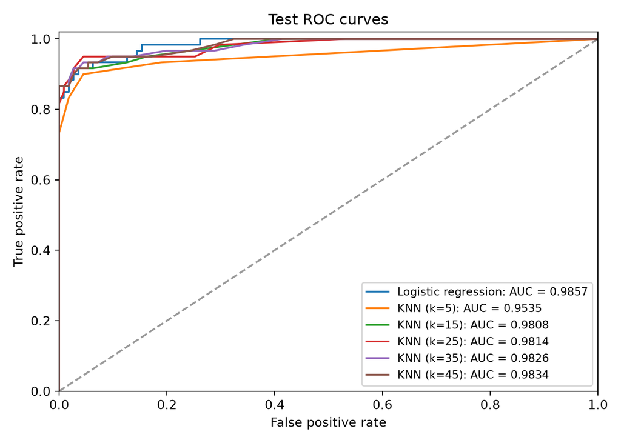

```python
ax.legend(loc="lower right", fontsize=9)
fig.tight_layout()
plt.show()
```

**Results and explanation:**

I prefer logistic regression because it has the highest test AUC (0.9857), slightly above the best KNN model ($k=45$, AUC 0.9834). In the same time it is a rather simpler model with only three predictors.

## Question 2: Training and test ROC curves

Use the same data, training/test split, and standardization as in Question 1. Fit KNN with Euclidean distance, equal neighbor weights, and

$$k\in\{1,3,5,10,20\}.$$

Use each fitted model to estimate probabilities for both the training and test observations. For training predictions, include each observation itself among its $k$ nearest neighbors.

For each $k$, use a separate panel to show the training and test ROC curves together. Report both AUC values.

Explain the difference between training and test performance and how it changes with $k$. In particular, explain what happens at $k=1$ and why training performance may not reflect performance on new observations.

### Answer 2

```python
# Reuse the training/test split and standardized predictors from Question 1.
k_values = [1, 3, 5, 10, 20]
fig, axes = plt.subplots(2, 3, figsize=(12, 8), sharex=True, sharey=True)
print(f"{'k':>3} {'Training AUC':>14} {'Test AUC':>10}")
```

```
  k   Training AUC   Test AUC
```

```python
q2_auc = {}

for k, ax in zip(k_values, axes.flat):
    model = KNeighborsClassifier(
        n_neighbors=k, weights="uniform", metric="euclidean"
    )
    model.fit(X_train, y_train)
    # Passing X_train explicitly includes each point itself as a neighbor.
    train_probs = model.predict_proba(X_train)[:, 1]
    test_probs = model.predict_proba(X_test)[:, 1]
    train_auc = roc_auc_score(y_train, train_probs)
    test_auc = roc_auc_score(y_test, test_probs)
    q2_auc[k] = (train_auc, test_auc)
    print(f"{k:3d} {train_auc:14.4f} {test_auc:10.4f}")

    for label, labels, probs, auc in [
        ("Training", y_train, train_probs, train_auc),
        ("Test", y_test, test_probs, test_auc)
    ]:
        fpr, tpr, _ = roc_curve(labels, probs)
        ax.plot(fpr, tpr, label=f"{label}: AUC = {auc:.4f}")
    ax.plot([0, 1], [0, 1], "k--", alpha=0.4)
    ax.set(title=f"KNN (k={k})", xlabel="False positive rate",
           ylabel="True positive rate", xlim=(0, 1), ylim=(0, 1.02))
    ax.legend(loc="lower right", fontsize=8)
```

```
KNeighborsClassifier(metric='euclidean', n_neighbors=1)
  1         1.0000     0.8896
[Text(0.5, 1.0, 'KNN (k=1)'), Text(0.5, 0, 'False positive rate'), Text(0, 0.5, 'True positive rate'), (0.0, 1.0), (0.0, 1.02)]
KNeighborsClassifier(metric='euclidean', n_neighbors=3)
  3         0.9901     0.9419
[Text(0.5, 1.0, 'KNN (k=3)'), Text(0.5, 0, 'False positive rate'), Text(0, 0.5, 'True positive rate'), (0.0, 1.0), (0.0, 1.02)]
KNeighborsClassifier(metric='euclidean')
  5         0.9829     0.9535
[Text(0.5, 1.0, 'KNN (k=5)'), Text(0.5, 0, 'False positive rate'), Text(0, 0.5, 'True positive rate'), (0.0, 1.0), (0.0, 1.02)]
KNeighborsClassifier(metric='euclidean', n_neighbors=10)
 10         0.9769     0.9749
[Text(0.5, 1.0, 'KNN (k=10)'), Text(0.5, 0, 'False positive rate'), Text(0, 0.5, 'True positive rate'), (0.0, 1.0), (0.0, 1.02)]
KNeighborsClassifier(metric='euclidean', n_neighbors=20)
 20         0.9810     0.9806
[Text(0.5, 1.0, 'KNN (k=20)'), Text(0.5, 0, 'False positive rate'), Text(0, 0.5, 'True positive rate'), (0.0, 1.0), (0.0, 1.02)]
```

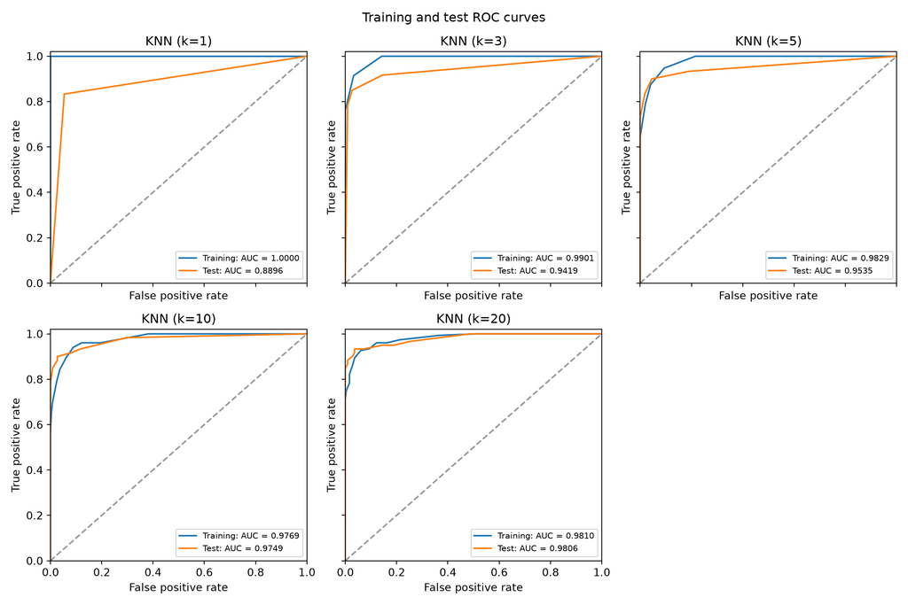

```python
axes.flat[-1].set_visible(False)
fig.suptitle("Training and test ROC curves")
fig.tight_layout()
plt.show()
```

**Results and explanation:**

At $k=1$, each training observation is its own nearest neighbor, so its estimated probability equals its label and training AUC is 1.0000. Test AUC is only 0.8896, showing overfitting. As $k$ increases to 20, averaging more neighbors smooths predictions: test AUC rises to 0.9806 and the training–test gap nearly disappears. Training AUC generally decreases, though not monotonically. Training performance is optimistic because it reuses observations used to fit the model; test performance better reflects predictions on new observations.

## Question 3: Peer evaluation of Homework 5

You will receive two Homework 5 submissions to review. The instructor’s GitHub account, **rqzhu-aide**, will open a **GitHub Issue** in the repository containing your Homework 5 submission. It will contain links to two other students’ repositories, where you can find their submitted homework reports.

Open your repository’s **Issues** tab on GitHub to find the assignment. You may ask AI to explain GitHub Issues or help you locate the assignment.

Choose **one specific mistake or item for improvement** from any question in either report.

1. **Identify the mistake or item for improvement.** State which report and question you selected, and briefly describe what is wrong or could be improved. Examples include incorrect code, a calculation error, a misinterpretation of results, a plot that could communicate the findings more clearly, or anything else you think could be done better.
2. **Explain your assessment.** Quote the relevant text, code, or figure caption exactly. Explain why the selected answer is incorrect or how it could be improved, referring to its reasoning, calculations, code, figures, or interpretation. **Complete this part yourself, without AI assistance.**
3. **Provide a correction.** Write a corrected or improved answer to the selected question, including any calculations, code, or figures needed.

After completing your review, **open a GitHub Issue in the repository containing the report you selected**. Identify the report and question, and include your assessment and a detailed revision plan explaining what the author should change and why. Include a link to your posted GitHub Issue in your Homework 6 answer.

### Answer 3

Link 1: https://github.com/AllyWangYijing/stat432-fall2026/issues/2

Link 2: https://github.com/raindrop110/stat432-fall2026/issues/2